# Project 1 Data Analysis

The extent of analysis of a dataset is largely up to the analyst. There is much subjectivity when deciding how to explore a dataset. How much is too much exploration, to a point where you are not getting any information from some charts? What if you do not explore enough, will you miss key patterns and correlations between variables?

For Project 1 exploration, since we are relatively new to analyzing your data, I will give you exactly what I need from your analysis. If you do the minimum exploration I have listed here, then you will get a 87%-90% on this portion of the project. If you add more insightful analysis on your own, you will get an A.

## Basics of Dataset

```python
#Find the size of your dataset (number of features and observations)
import pandas as pd

circuits = pd.read_csv('circuits.csv')
constructor_results = pd.read_csv('constructor_results.csv')
constructor_standings = pd.read_csv('constructor_standings.csv')
constructors = pd.read_csv('constructors.csv')
driver_standings = pd.read_csv('driver_standings.csv')
drivers = pd.read_csv('drivers.csv')
lap_times = pd.read_csv('lap_times.csv')
pit_stops = pd.read_csv('pit_stops.csv')
qualifying = pd.read_csv('qualifying.csv')
races = pd.read_csv('races.csv')
results = pd.read_csv('results.csv')
seasons = pd.read_csv('seasons.csv')
sprint_results = pd.read_csv('sprint_results.csv')
status = pd.read_csv('status.csv')
```

```python
print("Circuits shape:", circuits.shape)
print("Constructor Results shape:", constructor_results.shape)
print("Constructor Standings shape:", constructor_standings.shape)
print("constructors shape:", constructors.shape)
print("driver_standings:", driver_standings.shape)
print("drivers:", drivers.shape)
print("lap_times:", lap_times.shape)
print("pit_stops:", pit_stops.shape)
print("qualifying:", qualifying.shape)
print("races:", races.shape)
print("results:", results.shape)
print("seasons:", seasons.shape)
print("sprint_results:", sprint_results.shape)
print("status:", constructor_standings.shape)
```

[output not shown]

```python
total_rows = sum([df.shape[0] for df in [circuits, constructor_results, constructor_standings, constructors, driver_standings, drivers, lap_times, pit_stops, qualifying, races, results, seasons, sprint_results, status]])
total_columns = sum([df.shape[1] for df in [circuits, constructor_results, constructor_standings, constructors, driver_standings, drivers, lap_times, pit_stops, qualifying, races, results, seasons, sprint_results, status]])

print("Total Number of Columns (Features):", total_columns)
print("Total Number of Rows (Observations):", total_rows)
```

```
Total Number of Columns (Features): 120
Total Number of Rows (Observations): 659830
```

```python
import pandas as pd
csv_files = [
    'circuits.csv', 'constructor_results.csv', 'constructor_standings.csv',
    'constructors.csv', 'driver_standings.csv', 'drivers.csv', 'lap_times.csv',
    'pit_stops.csv', 'qualifying.csv', 'races.csv', 'results.csv', 'seasons.csv',
    'sprint_results.csv', 'status.csv'
]


for file in csv_files:
    print(f"Summary Statistics for {file}:")
    data = pd.read_csv(file)
    summary_statistics = data.describe(include='all')
    print(summary_statistics)
    print("-" * 50)
```

```
Summary Statistics for circuits.csv:
        circuitId   circuitRef                            name   location  \
count   77.000000           77                              77         77
unique        NaN           77                              77         75
top           NaN  albert_park  Albert Park Grand Prix Circuit  Barcelona
freq          NaN            1                               1          2
mean    39.883117          NaN                             NaN        NaN
std     23.001701          NaN                             NaN        NaN
min      1.000000          NaN                             NaN        NaN
25%     20.000000          NaN                             NaN        NaN
50%     40.000000          NaN                             NaN        NaN
75%     59.000000          NaN                             NaN        NaN
max     80.000000          NaN                             NaN        NaN

       country        lat         lng  alt  \
count       77  77.000000   77.000000   77
unique      35        NaN         NaN   66
top        USA        NaN         NaN   18
freq        11        NaN         NaN    3
mean       NaN  33.442925    1.076683  NaN
std        NaN  22.808866   65.516951  NaN
min        NaN -37.849700 -118.189000  NaN
25%        NaN  32.777400   -9.394170  NaN
50%        NaN  40.951700    3.930830  NaN
75%        NaN  46.958900   19.248600  NaN
max        NaN  57.265300  144.968000  NaN

                                                      url
count                                                  77
unique                                                 77
top     http://en.wikipedia.org/wiki/Melbourne_Grand_P...
freq                                                    1
mean                                                  NaN
std                                                   NaN
min                                                   NaN
25%                                                   NaN
50%                                                   NaN
75%                                                   NaN
max                                                   NaN
--------------------------------------------------
```

[output cut: 375 more lines]

```
--------------------------------------------------
Summary Statistics for status.csv:
          statusId    status
count   139.000000       139
unique         NaN       139
top            NaN  Finished
freq           NaN         1
mean     71.237410       NaN
std      41.092434       NaN
min       1.000000       NaN
25%      35.500000       NaN
50%      72.000000       NaN
75%     106.500000       NaN
max     141.000000       NaN
--------------------------------------------------
```

## Distribution of Dataset

```python
#Add at least one box and whisker plot of an important numerical variable in your table
```

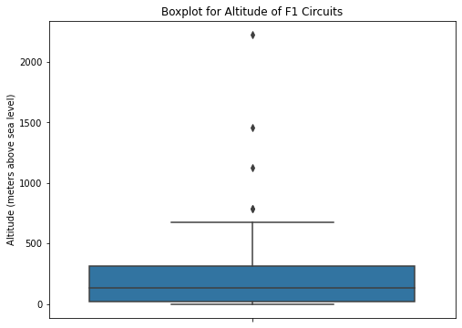

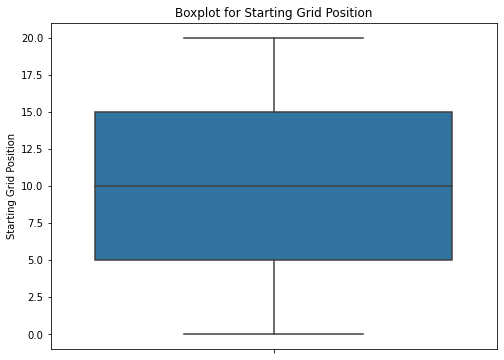

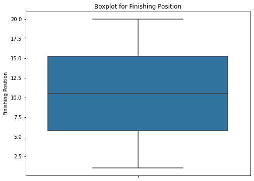

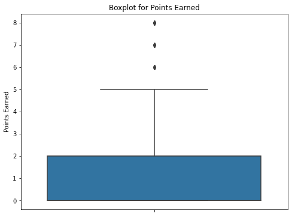

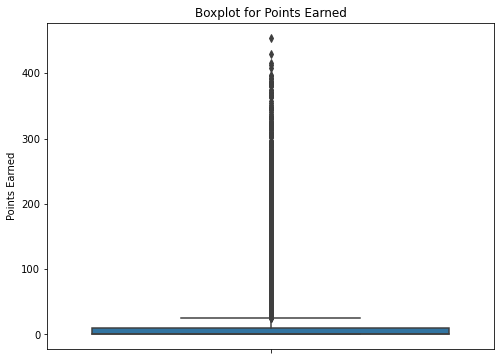

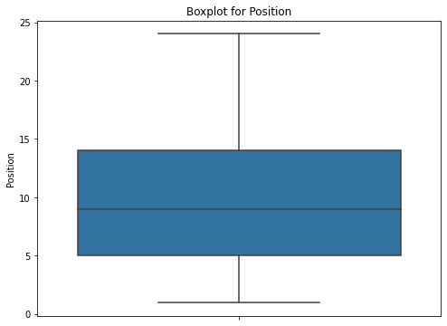

```python
import matplotlib.pyplot as plt
import seaborn as sns
import pandas as pd


circuits['alt'] = pd.to_numeric(circuits['alt'], errors='coerce')

plt.figure(figsize=(8, 6))
sns.boxplot(y='alt', data=circuits)
plt.title('Boxplot for Altitude of F1 Circuits')
plt.ylabel('Altitude (meters above sea level)')
plt.show()

plt.figure(figsize=(8, 6))
sns.boxplot(y='grid', data=sprint_results)
plt.title('Boxplot for Starting Grid Position')
plt.ylabel('Starting Grid Position')
plt.show()

plt.figure(figsize=(8, 6))
sns.boxplot(y='positionOrder', data=sprint_results)
plt.title('Boxplot for Finishing Position')
plt.ylabel('Finishing Position')
plt.show()

plt.figure(figsize=(8, 6))
sns.boxplot(y='points', data=sprint_results)
plt.title('Boxplot for Points Earned')
plt.ylabel('Points Earned')
plt.show()

plt.figure(figsize=(8, 6))
sns.boxplot(y='points', data=driver_standings)
plt.title('Boxplot for Points Earned')
plt.ylabel('Points Earned')
plt.show()

plt.figure(figsize=(8, 6))
sns.boxplot(y='position', data=lap_times)
plt.title('Boxplot for Position')
plt.ylabel('Position')
plt.show()
```

```python
#Add a correlation matrix of all your numerical variables and give written
#anlaysis of any variables that show strong correlation
```

Strongly correlated variables in constructor_results.csv: raceId and constructorResultsId (Correlation: 0.92)

Strongly correlated variables in qualifying.csv: raceId and qualifyId (Correlation: 0.92)

Strongly correlated variables in results.csv: raceId and resultId (Correlation: 0.97)

Strongly correlated variables in sprint_results.csv: raceId and resultId (Correlation: 0.99)

(please follow the outputs of the upcoming cells to understand how the above variables are found strongly correlated)

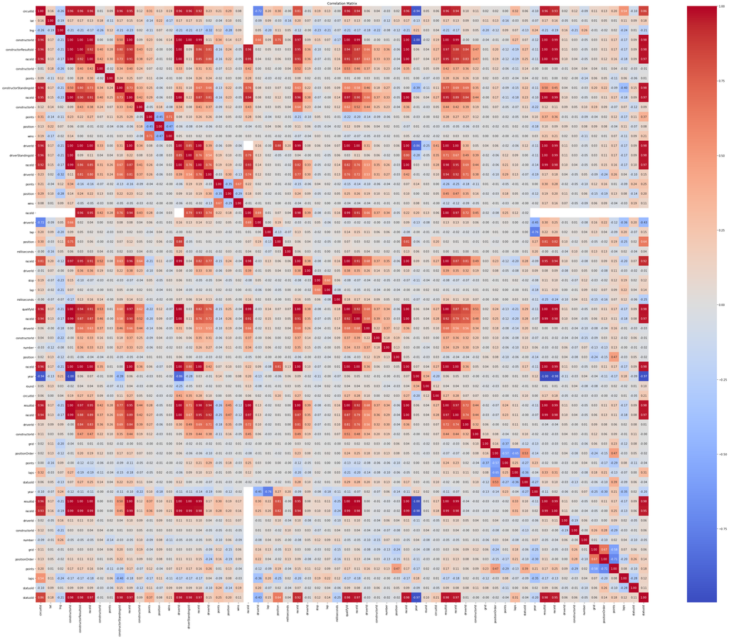

```python
import pandas as pd
import seaborn as sns
import matplotlib.pyplot as plt

data_frames = {}
for name in data_frame_names:
    df = pd.read_csv(f'{name}.csv')
    data_frames[name] = df

for key, df in data_frames.items():
    numerical_variables = df.select_dtypes(include=['number'])
    data_frames[key] = numerical_variables

combined_df = pd.concat(data_frames.values(), axis=1)

correlation_matrix = combined_df.corr()

plt.figure(figsize=(50, 40))
sns.heatmap(correlation_matrix, annot=True, cmap='coolwarm', fmt=".2f")
plt.title('Correlation Matrix')
plt.show()
```

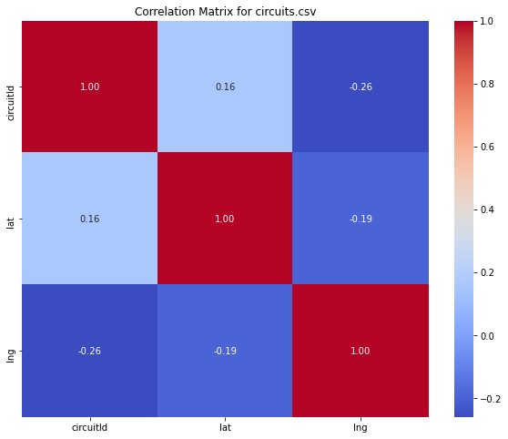

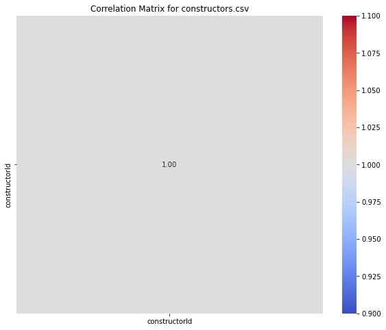

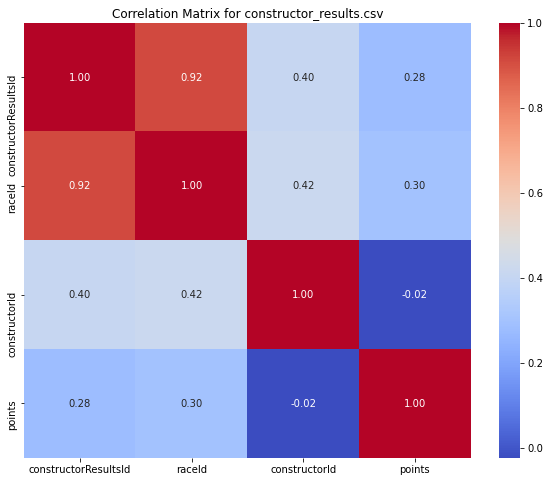

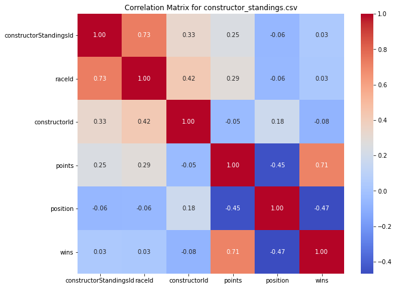

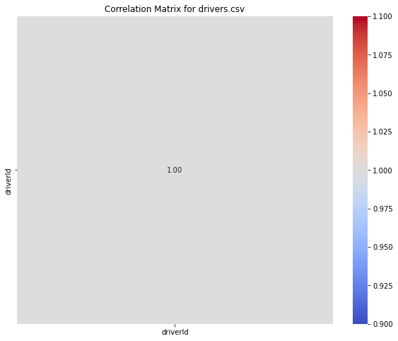

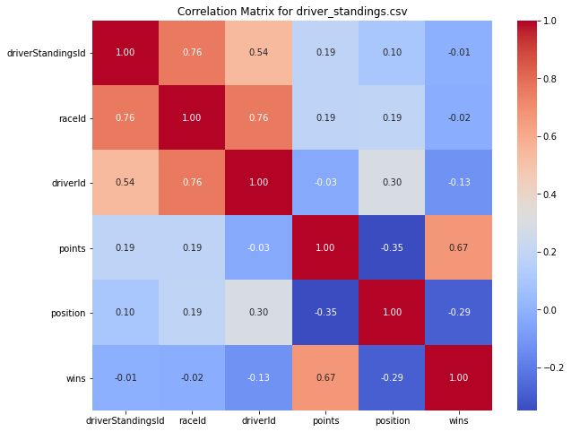

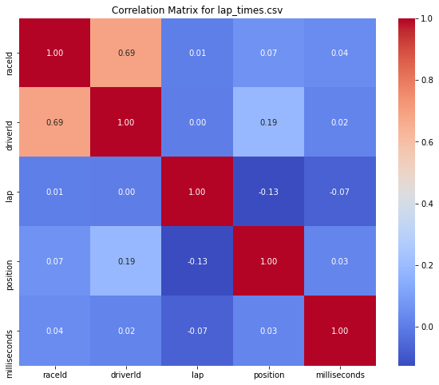

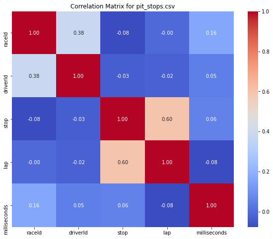

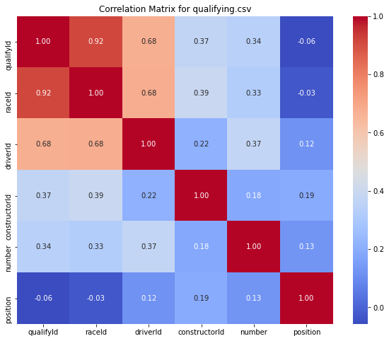

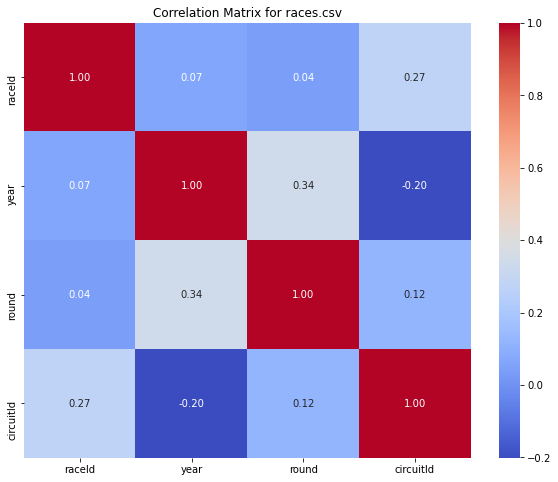

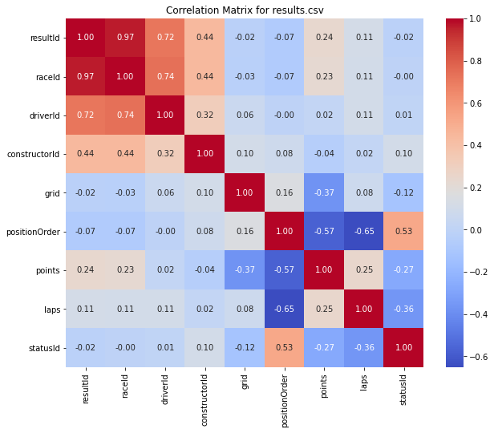

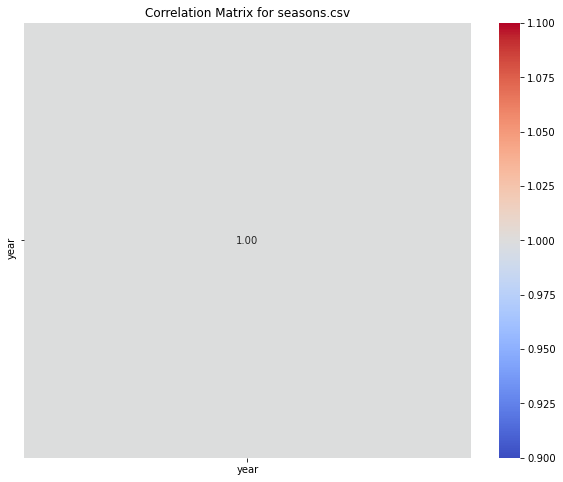

[2 more figures not shown]

```python
import pandas as pd
import seaborn as sns
import matplotlib.pyplot as plt

csv_files = [
    'circuits.csv',
    'constructors.csv',
    'constructor_results.csv',
    'constructor_standings.csv',
    'drivers.csv',
    'driver_standings.csv',
    'lap_times.csv',
    'pit_stops.csv',
    'qualifying.csv',
    'races.csv',
    'results.csv',
    'seasons.csv',
    'sprint_results.csv',
    'status.csv'
]

for csv_file in csv_files:
    df = pd.read_csv(csv_file)

    correlation_matrix = df.corr()

    plt.figure(figsize=(10, 8))
    sns.heatmap(correlation_matrix, annot=True, cmap='coolwarm', fmt=".2f")
    plt.title(f'Correlation Matrix for {csv_file}')
    plt.show()
```

```python
import pandas as pd
import seaborn as sns
import matplotlib.pyplot as plt

csv_files = [
    'circuits.csv',
    'constructors.csv',
    'constructor_results.csv',
    'constructor_standings.csv',
    'drivers.csv',
    'driver_standings.csv',
    'lap_times.csv',
    'pit_stops.csv',
    'qualifying.csv',
    'races.csv',
    'results.csv',
    'seasons.csv',
    'sprint_results.csv',
    'status.csv'
]

def find_strong_correlations(df, threshold):
    correlation_matrix = df.corr()
    strongly_correlated_pairs = []

    for i in range(len(correlation_matrix.columns)):
        for j in range(i):
            if abs(correlation_matrix.iloc[i, j]) > threshold:
                strongly_correlated_pairs.append((correlation_matrix.columns[i], correlation_matrix.columns[j], correlation_matrix.iloc[i, j]))

    return strongly_correlated_pairs

threshold = 0.8

for csv_file in csv_files:
    df = pd.read_csv(csv_file)

    strongly_correlated_vars = find_strong_correlations(df, threshold)

    if strongly_correlated_vars:
        print(f'Strongly correlated variables in {csv_file}:')
        for var1, var2, correlation in strongly_correlated_vars:
            print(f'{var1} and {var2} (Correlation: {correlation:.2f})')
        print('\n')
```

```
Strongly correlated variables in constructor_results.csv:
raceId and constructorResultsId (Correlation: 0.92)


Strongly correlated variables in qualifying.csv:
raceId and qualifyId (Correlation: 0.92)


Strongly correlated variables in results.csv:
raceId and resultId (Correlation: 0.97)


Strongly correlated variables in sprint_results.csv:
raceId and resultId (Correlation: 0.99)
```

```python
#BONUS: You can create a histogram to show distribution of a numerical variable
```

[figure not shown]

```python
import matplotlib.pyplot as plt
import pandas as pd

circuits_df = pd.read_csv('circuits.csv')

altitude_data = circuits_df['alt']

plt.figure(figsize=(10, 6))
plt.hist(altitude_data, bins=20, color='blue', alpha=0.7)
plt.title('Histogram of Altitude in Circuits')
plt.xlabel('Altitude (meters above sea level)')
plt.ylabel('Frequency')
plt.grid(True, linestyle='--', alpha=0.6)
plt.show()
```

## Aggregation of Categorical Data

```python
#Create either a bar chart or pie chart of the sum of one numerical value in
#relation to one categorical variable (i.e. sum of sales for each category of product)
```

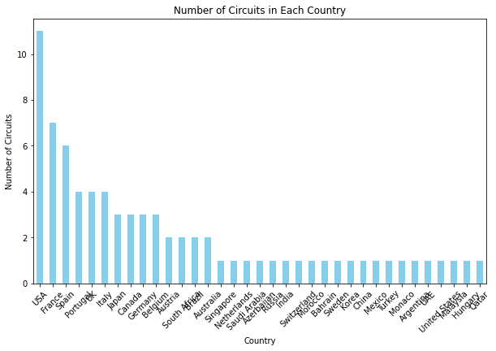

```python
import pandas as pd
import matplotlib.pyplot as plt

circuits_df = pd.read_csv('circuits.csv')

circuits_by_country = circuits_df['country'].value_counts()

plt.figure(figsize=(10, 6))
circuits_by_country.plot(kind='bar', color='skyblue')
plt.title('Number of Circuits in Each Country')
plt.xlabel('Country')
plt.ylabel('Number of Circuits')
plt.xticks(rotation=45)
plt.show()
```

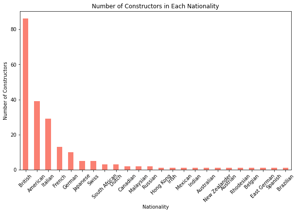

```python
import pandas as pd
import matplotlib.pyplot as plt

constructors_df = pd.read_csv('constructors.csv')

constructors_by_country = constructors_df['nationality'].value_counts()

plt.figure(figsize=(10, 6))
constructors_by_country.plot(kind='bar', color='salmon')
plt.title('Number of Constructors in Each Nationality')
plt.xlabel('Nationality')
plt.ylabel('Number of Constructors')
plt.xticks(rotation=45)
plt.show()
```

```python
#BONUS: Create a scatterplot with more than 2 visual encodings
```

```
<function matplotlib.pyplot.show(close=None, block=None)>
```

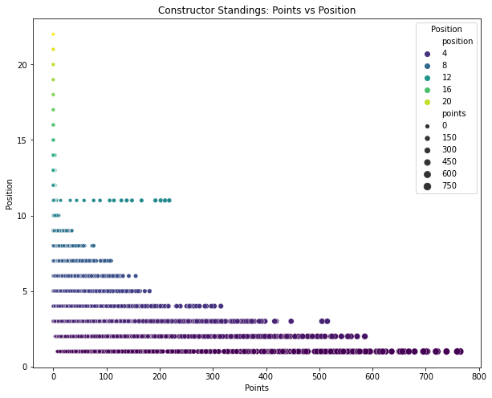

```python
import pandas as pd
import matplotlib.pyplot as plt
import seaborn as sns

constructor_standings_df = pd.read_csv('constructor_standings.csv')

size_encoding = constructor_standings_df['points']

color_encoding = constructor_standings_df['position']

plt.figure(figsize=(10, 8))
scatter_plot = sns.scatterplot(x=size_encoding, y=color_encoding, size=size_encoding, hue=color_encoding, palette='viridis')

scatter_plot.set_title('Constructor Standings: Points vs Position')
plt.xlabel('Points')
plt.ylabel('Position')
plt.legend(title='Position')
plt.show
```

## Insights & Trends

Here you can include some key conclusions you can make of your dataset based on your analysis above. What visualizations do you hope to create based on what patterns you have observed in your dataset? What trends have you noticed that will help with your investigation into this topic?

Strong correlations between race identifiers and outcome identifiers indicate a robust linkage in the dataset. The key visualizations and trends I plan to explore:

Scatter Plots for Correlation Analysis: Creating scatter plots for strongly correlated variables to visually examine their relationships. Time Series Analysis: Investigating trends in specific metrics over time using line plots or time series visualizations. Geospatial Mapping: Mapping circuits globally to understand their distribution and identify regional clusters. Comparative Analysis: Side-by-side visualizations to compare performance metrics of different drivers, constructors, or circuits for pattern recognition.